## The data consist of all the information of a restaurent such as bill, tip, sex, smoker etc. and we would be using Linear Regression Model to analyze the given data.

#### Importing different libraries such as numpy, pandas, matplotlib and seaborn.

```python
import numpy as np
import pandas as pd

## for visualization
import matplotlib.pyplot as plt
import seaborn as sns
```

```python
tips = sns.load_dataset('tips')
```

```python
tips.head(2)
```

|  | total_bill | tip | sex | smoker | day | time | size |
| --- | --- | --- | --- | --- | --- | --- | --- |
| 0 | 16.99 | 1.01 | Female | No | Sun | Dinner | 2 |
| 1 | 10.34 | 1.66 | Male | No | Sun | Dinner | 3 |

#### info() method is used to see all the information about the dataset.

```python
tips.info()
```

```
<class 'pandas.core.frame.DataFrame'>
RangeIndex: 244 entries, 0 to 243
Data columns (total 7 columns):
 #   Column      Non-Null Count  Dtype
---  ------      --------------  -----
 0   total_bill  244 non-null    float64
 1   tip         244 non-null    float64
 2   sex         244 non-null    category
 3   smoker      244 non-null    category
 4   day         244 non-null    category
 5   time        244 non-null    category
 6   size        244 non-null    int64
dtypes: category(4), float64(2), int64(1)
memory usage: 7.4 KB
```

#### In this describe is used to get the percentiles so that outliers can be identified.

```python
tips.describe(percentiles = [0.8,0.9,0.95,0.99,1]).T
```

|  | count | mean | std | min | 50% | 80% | 90% | 95% | 99% | 100% | max |
| --- | --- | --- | --- | --- | --- | --- | --- | --- | --- | --- | --- |
| total_bill | 244.0 | 19.785943 | 8.902412 | 3.07 | 17.795 | 26.098 | 32.235 | 38.0610 | 48.2270 | 50.81 | 50.81 |
| tip | 244.0 | 2.998279 | 1.383638 | 1.00 | 2.900 | 4.000 | 5.000 | 5.1955 | 7.2145 | 10.00 | 10.00 |
| size | 244.0 | 2.569672 | 0.951100 | 1.00 | 2.000 | 3.000 | 4.000 | 4.0000 | 6.0000 | 6.00 | 6.00 |

#### During outlier treatment the top and outliers are identified, it can be top 1% and bottom 1%, top 5% and bottom 5% and so on depending on the requirement.

Outlier Treatment - Just consider the top 1% and bottom 1% of the data as outliers. p1p99 p5p95 p10p90

#### In this case we are going for top 5% and bottom 5%.

```python
lower_cutoff = tips.tip.quantile(0.05)
```

```python
upper_cutoff = tips.tip.quantile(0.95)
```

```python
tips['tip'] = tips.tip.clip(lower_cutoff, upper_cutoff)
```

```python
tips.describe().T
```

|  | count | mean | std | min | 25% | 50% | 75% | max |
| --- | --- | --- | --- | --- | --- | --- | --- | --- |
| total_bill | 244.0 | 19.785943 | 8.902412 | 3.07 | 13.3475 | 17.795 | 24.1275 | 50.8100 |
| tip | 244.0 | 2.932219 | 1.133096 | 1.44 | 2.0000 | 2.900 | 3.5625 | 5.1955 |
| size | 244.0 | 2.569672 | 0.951100 | 1.00 | 2.0000 | 2.000 | 3.0000 | 6.0000 |

#### df.clip() is used to trim off the decided lower and upper cutoff. It does not drop the rows that are outside the specified range by the upper and lower values. Instead, if a value is outside the boundaries, the clip function makes them equal to the appropriate boundary value.

```python
def outlier_treatment(x):
    lower = x.quantile(0.05)
    upper = x.quantile(0.95)

    return x.clip(lower, upper)
```

```python
tips['total_bill'] = outlier_treatment(tips.total_bill)
```

```python
tips.describe().T
```

|  | count | mean | std | min | 25% | 50% | 75% | max |
| --- | --- | --- | --- | --- | --- | --- | --- | --- |
| total_bill | 244.0 | 19.598076 | 7.961556 | 9.5575 | 13.3475 | 17.795 | 24.1275 | 38.0610 |
| tip | 244.0 | 2.932219 | 1.133096 | 1.4400 | 2.0000 | 2.900 | 3.5625 | 5.1955 |
| size | 244.0 | 2.569672 | 0.951100 | 1.0000 | 2.0000 | 2.000 | 3.0000 | 6.0000 |

#### As the outliers are treated, then we go for EDA(Exploratory Data Analysis)

### Exploratory Data Analysis Exploratory Data Analysis(EDA) is an approach to analyzing datasets to summarize their main characteristics, often with visual methods.Split the data into continuous and categorical variables.

```python
tips_continuous = tips.select_dtypes('number')
```

```python
tips_continuous.head(2)
```

|  | total_bill | tip | size |
| --- | --- | --- | --- |
| 0 | 16.99 | 1.44 | 2 |
| 1 | 10.34 | 1.66 | 3 |

```python
tips_categorical = tips.select_dtypes('category')
```

```python
tips_categorical.head(2)
```

|  | sex | smoker | day | time |
| --- | --- | --- | --- | --- |
| 0 | Female | No | Sun | Dinner |
| 1 | Male | No | Sun | Dinner |

Univariate Analysis of continuous columns

#### Univariate Analysis is the simplest form of analysing data. It is used for the analysis of a single column or variable.

#### To see the distribution of the columns for univariate analysis.

We can plot:

- Histogram
- Boxplots

```python
def univariate_continuous(x):

    print('Analysis for', x.name)
    x.hist()
    plt.ylabel('Frequency')
    plt.xlabel(x.name)
    plt.show()
```

```
Analysis for total_bill
```

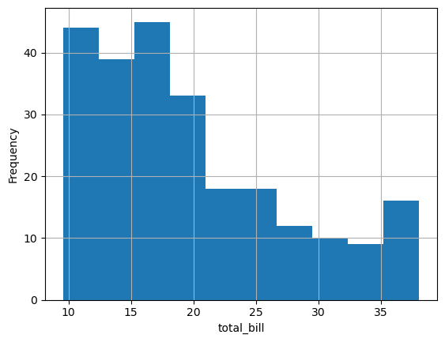

```
Analysis for tip
```

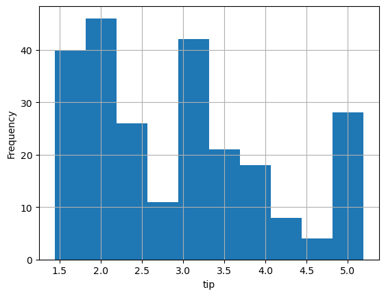

```
Analysis for size
```

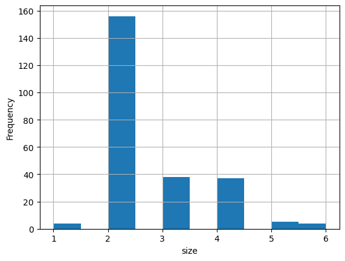

```
total_bill    None
tip           None
size          None
dtype: object
```

```python
tips_continuous.apply(univariate_continuous)
```

#### Bivariate Analysis

- Continuous vs Continuous

```python
tips_continuous.corr()
```

|  | total_bill | tip | size |
| --- | --- | --- | --- |
| total_bill | 1.000000 | 0.653489 | 0.604297 |
| tip | 0.653489 | 1.000000 | 0.502207 |
| size | 0.604297 | 0.502207 | 1.000000 |

-- tip and total_bill have a good linear relationship -- tip and size are also sharing a good relationship

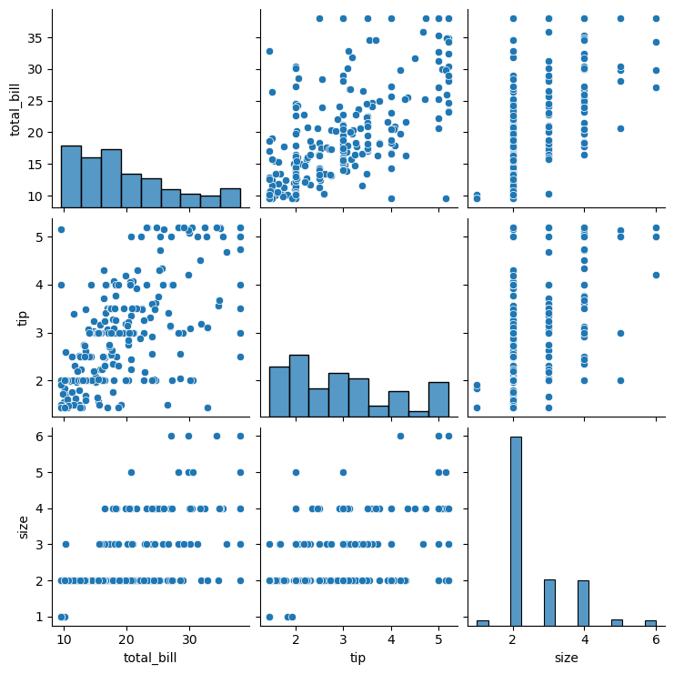

```python
sns.pairplot(tips_continuous)
```

Categorical variables vs tip --boxplot

```python
tips.sex
```

```
0      Female
1        Male
2        Male
3        Male
4      Female
        ...
239      Male
240    Female
241      Male
242      Male
243    Female
Name: sex, Length: 244, dtype: category
Categories (2, object): ['Male', 'Female']
```

```python
tips.tip
```

```
0      1.4400
1      1.6600
2      3.5000
3      3.3100
4      3.6100
        ...
239    5.1955
240    2.0000
241    2.0000
242    1.7500
243    3.0000
Name: tip, Length: 244, dtype: float64
```

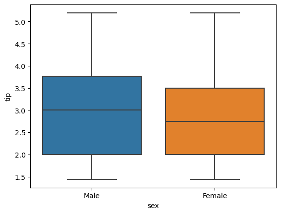

```python
sns.boxplot(x = tips.sex, y = tips.tip)
```

#### From the above boxplot, males give a bit more tip than females.

#### Now creating a formula to create a chart between categorical columns(sex,smoker,day,time) and tips.

```python
def cat_vs_tip(x):
    print('Analysis for',x.name)
    sns.boxplot(x=x,y=tips.tip)
    plt.show()
```

```
Analysis for sex
```

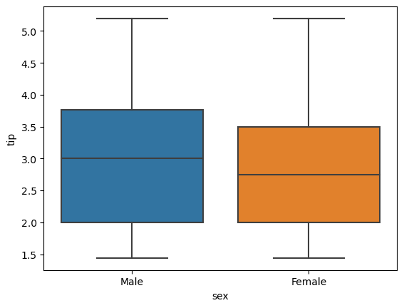

```
Analysis for smoker
```

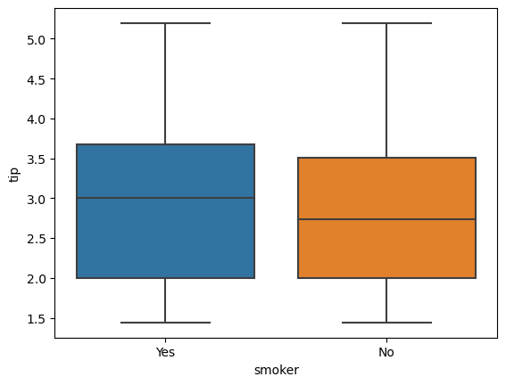

```
Analysis for day
```

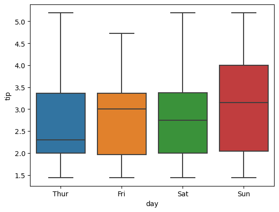

```
Analysis for time
```

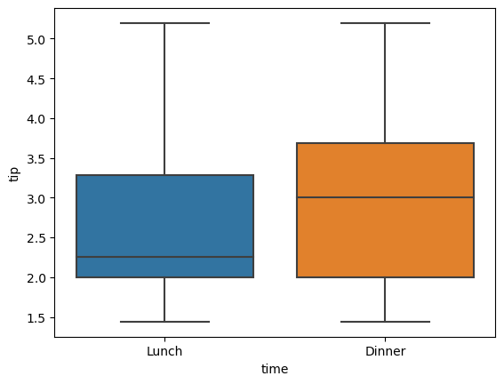

```
sex       None
smoker    None
day       None
time      None
dtype: object
```

```python
tips_categorical.apply(cat_vs_tip)
```

#### From the above given boxplots;

The Insights are:

- Smoker pay a bit higher tip than non-smokers.
- In all the days, people tend to give the most tips on Sunday.
- Most tips are given at dinner time.

#### Scikit-Learn or sklearn is a python library, used to implement machine learning models and statistical models.

sklearn

#### from sklearn we have imported test_train_split

```python
from sklearn.model_selection import train_test_split
```

#### The test_train_split from sklearn is used to divide the data into training data and testing data, so that if a model is made on training data, than it could also be used on testing data to judge the model's accuracy.

#### In this case 20% data has been taken into testing data so automatically the rest would have went in training data.

```python
tips_train, tips_test = train_test_split(tips, test_size = 0.2)
```

```python
tips_train.shape
```

```
(195, 7)
```

```python
tips_test.shape
```

```
(49, 7)
```

#### Dividing the data into qualitative and quantitative data types.

```python
tips.select_dtypes('category')
```

|  | sex | smoker | day | time |
| --- | --- | --- | --- | --- |
| 0 | Female | No | Sun | Dinner |
| 1 | Male | No | Sun | Dinner |
| 2 | Male | No | Sun | Dinner |
| 3 | Male | No | Sun | Dinner |
| 4 | Female | No | Sun | Dinner |
| ... | ... | ... | ... | ... |
| 239 | Male | No | Sat | Dinner |
| 240 | Female | Yes | Sat | Dinner |
| 241 | Male | Yes | Sat | Dinner |
| 242 | Male | No | Sat | Dinner |
| 243 | Female | No | Thur | Dinner |

244 rows × 4 columns

#### By using pd.get_dummies the categorical data would create one-hot-encoding, and would create the categorical data into 0 and 1, because in machine-learning models, the machine can only identify 0 and 1, it can't identify any word as such,

```python
pd.get_dummies(tips.select_dtypes('category')).head(2)
```

|  | sex_Male | sex_Female | smoker_Yes | smoker_No | day_Thur | day_Fri | day_Sat | day_Sun | time_Lunch | time_Dinner |
| --- | --- | --- | --- | --- | --- | --- | --- | --- | --- | --- |
| 0 | 0 | 1 | 0 | 1 | 0 | 0 | 0 | 1 | 0 | 1 |
| 1 | 1 | 0 | 0 | 1 | 0 | 0 | 0 | 1 | 0 | 1 |

#### In here the drop_first is used it is used to drop the first column after one-hot-encoding it.

```python
tips_cat_one_hot = pd.get_dummies(tips.select_dtypes('category'),drop_first = True)
```

```python
tips_num = tips.select_dtypes('number')
```

```python
tips_final = pd.concat([tips_cat_one_hot, tips_num], axis = 1)
```

```python
tips_final.head(2)
```

|  | sex_Female | smoker_No | day_Fri | day_Sat | day_Sun | time_Dinner | total_bill | tip | size |
| --- | --- | --- | --- | --- | --- | --- | --- | --- | --- |
| 0 | 1 | 1 | 0 | 0 | 1 | 1 | 16.99 | 1.44 | 2 |
| 1 | 0 | 1 | 0 | 0 | 1 | 1 | 10.34 | 1.66 | 3 |

Train test split

```python
tips_train, tips_test = train_test_split(tips_final, test_size = 0.2, random_state = 0)
```

```python
tips_train.shape
```

```
(195, 9)
```

```python
tips_train.shape
```

```
(195, 9)
```

#### Linear Regression

-- To figure out the line of best fit it will try to optimize the cost function which in this case is sum of squared errors.

```python
tips.total_bill
```

```
0      16.99
1      10.34
2      21.01
3      23.68
4      24.59
       ...
239    29.03
240    27.18
241    22.67
242    17.82
243    18.78
Name: total_bill, Length: 244, dtype: float64
```

```python
tips.tip
```

```
0      1.4400
1      1.6600
2      3.5000
3      3.3100
4      3.6100
        ...
239    5.1955
240    2.0000
241    2.0000
242    1.7500
243    3.0000
Name: tip, Length: 244, dtype: float64
```

#### Creating a scatterplot to see the relationship between tip and total bill.

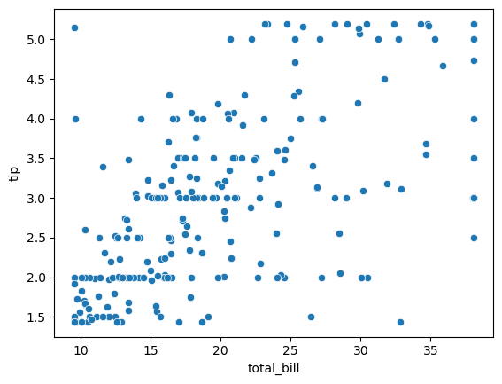

```python
sns.scatterplot(tips.total_bill, tips.tip)
```

#### From the graph it can easily be seen that tip and total_bill have a linear relationship.

Linear regression using statsmodels

```python
import statsmodels.formula.api as smf
```

```python
list(tips_train.columns)
```

```
['sex_Female',
 'smoker_No',
 'day_Fri',
 'day_Sat',
 'day_Sun',
 'time_Dinner',
 'total_bill',
 'tip',
 'size']
```

```python
' + '.join(list( tips_train.columns ))
```

```
'sex_Female + smoker_No + day_Fri + day_Sat + day_Sun + time_Dinner + total_bill + tip + size'
```

```python
formula1 = 'tip~sex_Female + smoker_No + day_Fri + day_Sat + day_Sun + time_Dinner + total_bill + tip + size'
```

```python
model = smf.ols(formula1,tips_train)
```

```python
model = model.fit()
```

R squared value: % of error explained by the best fit line over and above the naive prediction

Mean = SST Regression line = SSR Total benefit of the model = SST - SSR

R2 = (SST - SSR)/SST

SST = Sum of squared error. SSR = Sum of squared regression.

```python
print(model.summary())
```

```
                            OLS Regression Results
==============================================================================
Dep. Variable:                    tip   R-squared:                       1.000
Model:                            OLS   Adj. R-squared:                  1.000
Method:                 Least Squares   F-statistic:                 2.202e+28
Date:                Thu, 03 Aug 2023   Prob (F-statistic):               0.00
Time:                        20:40:26   Log-Likelihood:                 5766.6
No. Observations:                 195   AIC:                        -1.151e+04
Df Residuals:                     185   BIC:                        -1.148e+04
Df Model:                           9
Covariance Type:            nonrobust
===============================================================================
                  coef    std err          t      P>|t|      [0.025      0.975]
-------------------------------------------------------------------------------
Intercept   -2.498e-15   1.05e-14     -0.237      0.813   -2.33e-14    1.83e-14
sex_Female   1.388e-16   5.65e-15      0.025      0.980    -1.1e-14    1.13e-14
smoker_No   -4.996e-16   5.79e-15     -0.086      0.931   -1.19e-14    1.09e-14
day_Fri      3.886e-16   2.64e-14      0.015      0.988   -5.16e-14    5.24e-14
day_Sat      1.166e-15   2.86e-14      0.041      0.968   -5.53e-14    5.76e-14
day_Sun      2.331e-15   2.85e-14      0.082      0.935    -5.4e-14    5.87e-14
time_Dinner          0   2.79e-14          0      1.000   -5.51e-14    5.51e-14
total_bill  -1.498e-15    4.6e-16     -3.258      0.001    -2.4e-15   -5.91e-16
tip             1.0000   2.98e-15   3.35e+14      0.000       1.000       1.000
size         2.776e-16   3.52e-15      0.079      0.937   -6.67e-15    7.23e-15
==============================================================================
Omnibus:                       16.225   Durbin-Watson:                   0.231
Prob(Omnibus):                  0.000   Jarque-Bera (JB):               18.185
Skew:                           0.727   Prob(JB):                     0.000112
Kurtosis:                       2.648   Cond. No.                         470.
==============================================================================

Notes:
[1] Standard Errors assume that the covariance matrix of the errors is correctly specified.
```

#### From the above model it can be seen that the Female sex does not affect the tip. So we have to remove the Female sex and create a new formula that does not involve Female sex.

```python
formula2 = 'tip~smoker_No + day_Fri + day_Sat + day_Sun + time_Dinner + total_bill + size'
```

```python
model1 = smf.ols(formula2, tips_train)
```

```python
model1 = model1.fit()
```

```python
print(model1.summary())
```

```
                            OLS Regression Results
==============================================================================
Dep. Variable:                    tip   R-squared:                       0.432
Model:                            OLS   Adj. R-squared:                  0.411
Method:                 Least Squares   F-statistic:                     20.30
Date:                Thu, 03 Aug 2023   Prob (F-statistic):           3.76e-20
Time:                        20:48:35   Log-Likelihood:                -246.55
No. Observations:                 195   AIC:                             509.1
Df Residuals:                     187   BIC:                             535.3
Df Model:                           7
Covariance Type:            nonrobust
===============================================================================
                  coef    std err          t      P>|t|      [0.025      0.975]
-------------------------------------------------------------------------------
Intercept       0.9515      0.237      4.015      0.000       0.484       1.419
smoker_No       0.0068      0.142      0.048      0.962      -0.273       0.287
day_Fri         0.5018      0.642      0.781      0.436      -0.765       1.769
day_Sat         0.1270      0.699      0.182      0.856      -1.253       1.507
day_Sun         0.3450      0.698      0.494      0.622      -1.032       1.722
time_Dinner    -0.3366      0.679     -0.495      0.621      -1.677       1.004
total_bill      0.0751      0.010      7.630      0.000       0.056       0.095
size            0.2020      0.085      2.373      0.019       0.034       0.370
==============================================================================
Omnibus:                        5.673   Durbin-Watson:                   1.983
Prob(Omnibus):                  0.059   Jarque-Bera (JB):                5.309
Skew:                           0.355   Prob(JB):                       0.0703
Kurtosis:                       3.387   Cond. No.                         463.
==============================================================================

Notes:
[1] Standard Errors assume that the covariance matrix of the errors is correctly specified.
```

#### From the above model, it can be seen that the other attributes such as Smoker, Day and Dinner time doesn't give any such relevance, so a new formula would be created in which total bill and size would be used.

```python
formula3 = 'tip~total_bill + size'
```

```python
model2 = smf.ols(formula3,tips_train)
```

```python
model2 = model2.fit()
```

```python
print(model2.summary())
```

```
                            OLS Regression Results
==============================================================================
Dep. Variable:                    tip   R-squared:                       0.419
Model:                            OLS   Adj. R-squared:                  0.413
Method:                 Least Squares   F-statistic:                     69.26
Date:                Thu, 03 Aug 2023   Prob (F-statistic):           2.25e-23
Time:                        20:51:25   Log-Likelihood:                -248.70
No. Observations:                 195   AIC:                             503.4
Df Residuals:                     192   BIC:                             513.2
Df Model:                           2
Covariance Type:            nonrobust
==============================================================================
                 coef    std err          t      P>|t|      [0.025      0.975]
------------------------------------------------------------------------------
Intercept      0.9131      0.193      4.728      0.000       0.532       1.294
total_bill     0.0737      0.009      7.838      0.000       0.055       0.092
size           0.2068      0.081      2.544      0.012       0.046       0.367
==============================================================================
Omnibus:                        4.784   Durbin-Watson:                   2.007
Prob(Omnibus):                  0.091   Jarque-Bera (JB):                4.405
Skew:                           0.311   Prob(JB):                        0.111
Kurtosis:                       3.395   Cond. No.                         69.1
==============================================================================

Notes:
[1] Standard Errors assume that the covariance matrix of the errors is correctly specified.
```

```python
train_predictions = model2.predict(tips_train)
```

```python
tips_train.tip
```

```
7      3.1200
83     5.0000
176    2.0000
106    4.0600
156    5.0000
        ...
67     1.4400
192    2.5600
117    1.5000
47     5.1955
172    5.1500
Name: tip, Length: 195, dtype: float64
```

```python
##Predictions:Test_data

tips_test.tip
```

```
64     2.6400
63     3.7600
55     3.5100
111    1.4400
225    2.5000
92     1.4400
76     3.0800
181    5.1955
188    3.5000
180    3.6800
73     5.0000
107    4.2900
150    2.5000
198    2.0000
224    1.5800
```

[output cut: 35 more lines]

```python
test_predictions = model2.predict(tips_test)
```

```python
tips_test.tip.head(2)
```

```
64    2.64
63    3.76
Name: tip, dtype: float64
```

Test Matrics

#### from sklearn library we have imported the metrics to calculate the errors.

```python
from sklearn.metrics import mean_absolute_percentage_error, mean_absolute_error, mean_squared_error
```

```python
mean_absolute_percentage_error(tips_train.tip, train_predictions)
```

```
0.26441696632653966
```

```python
#### So in case of train data, we can see that the absolute percentage error is 0.26.
```

Testing data:

```python
mean_absolute_percentage_error(tips_test.tip, test_predictions)
```

```
0.1990957765713758
```

```python
#### In case of test data, we see that the absolute percentage error is 0.19.
```